# Visualização de Dados - ggplot2

Este notebook apresenta conceitos básicos da biblioteca de visualização de dados [ggplot2](https://ggplot2.tidyverse.org/).

## Leitura e análise inicial dos dados

```r
# Importação de Bibliotecas
library(ggplot2)
library(dplyr)
library(lubridate)

# lê o arquivo CSV
# lê o arquivo CSV
df <- read.csv('../data/aluguel.csv', header = T, sep=",", stringsAsFactors = FALSE)
df$data <- as.Date(df$data,format="%d/%m/%y")
df$vaga <- as.factor(df$vaga)
```

Vamos utilizar um dataset de ofertas de aluguel. O primeiro passo ao se analisar dados desconhecidos é visualizar algumas linhas de dados:

```r
head(df, 10)
```

```
##    codigo                       endereco quartos suite area vaga aluguel
## 1      34   Rua Desembargador Westphalen       2     0   90    0     900
## 2     167              Rua Jose Loureiro       2     0   64    0     650
## 3    6784              Rua Jose Loureiro       2     0   81    0    1100
## 4      82             Rua Lourenço Pinto       2     0   50    0    1350
## 5    2970             Rua Lourenço Pinto       2     0   63    0    1300
## 6   34197          Alameda Doutor Muricy       2     0   80    1     900
## 7    5072          Alameda Doutor Muricy       2     0   84    0    1100
## 8     469   Rua Desembargador Westphalen       1     0   30    0     550
## 9      24   Rua Desembargador Westphalen       1     0   60    1     800
## 10     74 Avenida Visconde de Guarapuava       2     1  132    1    1800
##    condominio       data
## 1         371 2017-10-11
## 2         428 2017-07-15
## 3         400 2017-08-23
## 4         300 2017-09-19
## 5         300 2017-08-05
## 6         410 2017-10-23
## 7         382 2017-09-02
## 8         210 2017-07-03
## 9         120 2017-09-30
## 10        520 2017-10-12
```

Vamos usar em alguns exemplos um DataFrame com os valores de condomínio e aluguel agregados por mês da oferta:

```r
df_mensal <- df %>%
  group_by(mes=floor_date(data, "month")) %>%
  summarize(aluguel=mean(aluguel),
            condominio=mean(condominio)
            )

df_mensal
```

```
## # A tibble: 4 × 3
##   mes        aluguel condominio
##   <date>       <dbl>      <dbl>
## 1 2017-07-01     670       314.
## 2 2017-08-01    1000       346
## 3 2017-09-01     942       269.
## 4 2017-10-01     980       414.
```

# ggplot2 - conceitos básicos

A biblioteca ggplot2 usa, em geral, uma sequência de passos para definir um gráfico. A sequência começa com a definição dos dados da plotagem (função `ggplot`) bem como suas especificações estéticas (função `aes`). Depois disso, adicionamos camadas com as visualizações desejadas. Opcionalmente, podemos incrementar o gráfico com legendas, escalas, sistemas de coordenadas, etc.

O exemplo abaixo define a estética (aes) como apenas a variável `aluguel` e adiciona uma camada com uma plotagem de histograma (geom_histogram).

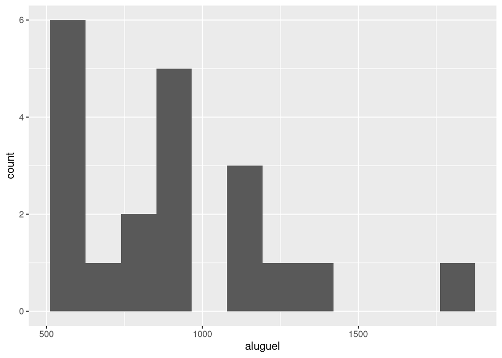

```r
ggplot(df, aes(aluguel)) +
  geom_histogram(bins = 12)
```

# Correlação

Podemos também definir mais variáveis na estética, como no gráfico de dispersão abaixo.

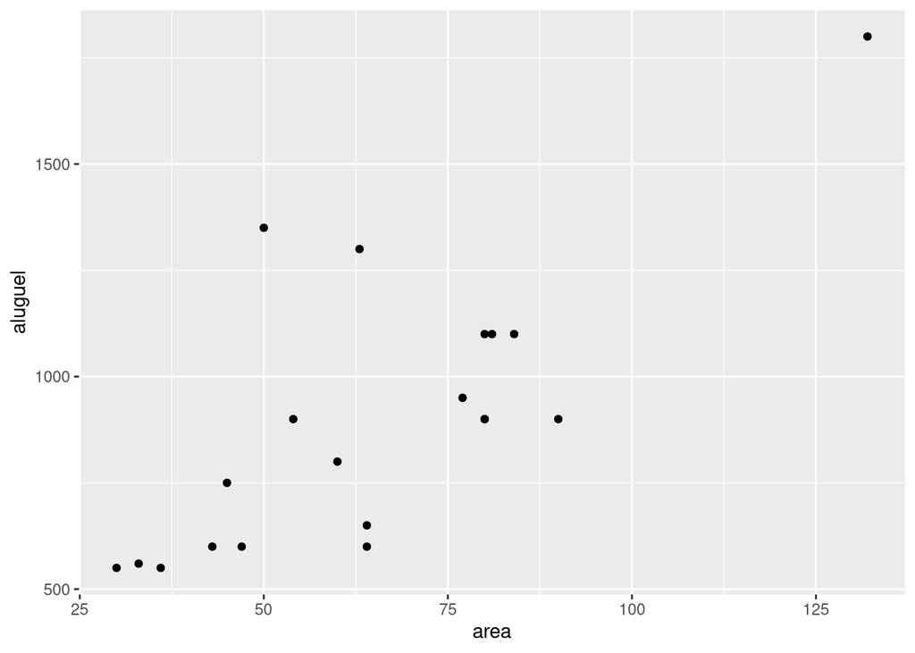

```r
ggplot(df, aes(area, aluguel)) +
  geom_point()
```

Podemos adicionar cores baseadas em uma terceira variável:

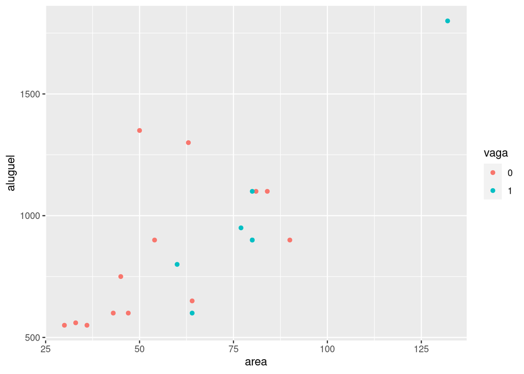

```r
g <- ggplot(df, aes(area, aluguel, colour = vaga)) +
  geom_point()

g
```

Ainda com o gráfico de dispersão construído anteriormente, podemos aproveitar a mesma variável (g) e acrescentar uma camada com as retas de tendência para os pontos. Abaixo configuramos também os títulos e eixos da figura.

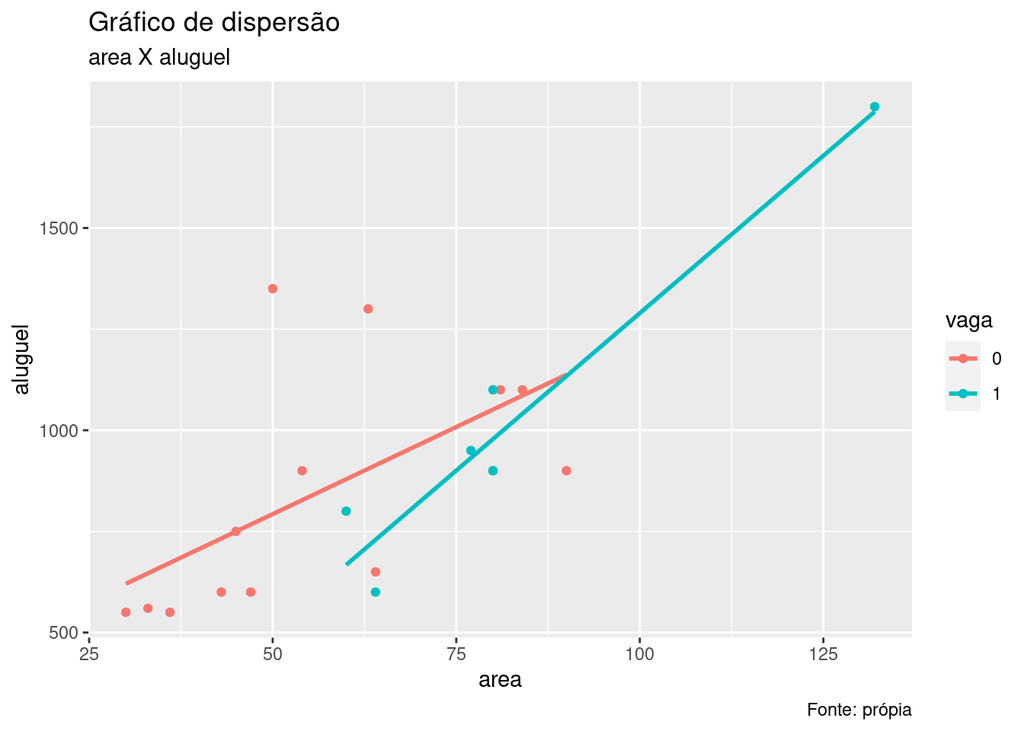

```r
 g +
  geom_smooth(method="lm", se=F) +
  labs(subtitle="area X aluguel",
       y="aluguel",
       x="area",
       title="Gráfico de dispersão",
       caption="Fonte: própia")
```

# Comparações Nominais

Para comparações de valores nominais, frequentemente usamos gráficos de barras. Abaixo montamos um gráfico de barras para a contagem de ofertas de apartamento dependendo da existência de vaga de garagem. A contagem é feita automaticamente a partir da configuração do parâmetro `stat`.

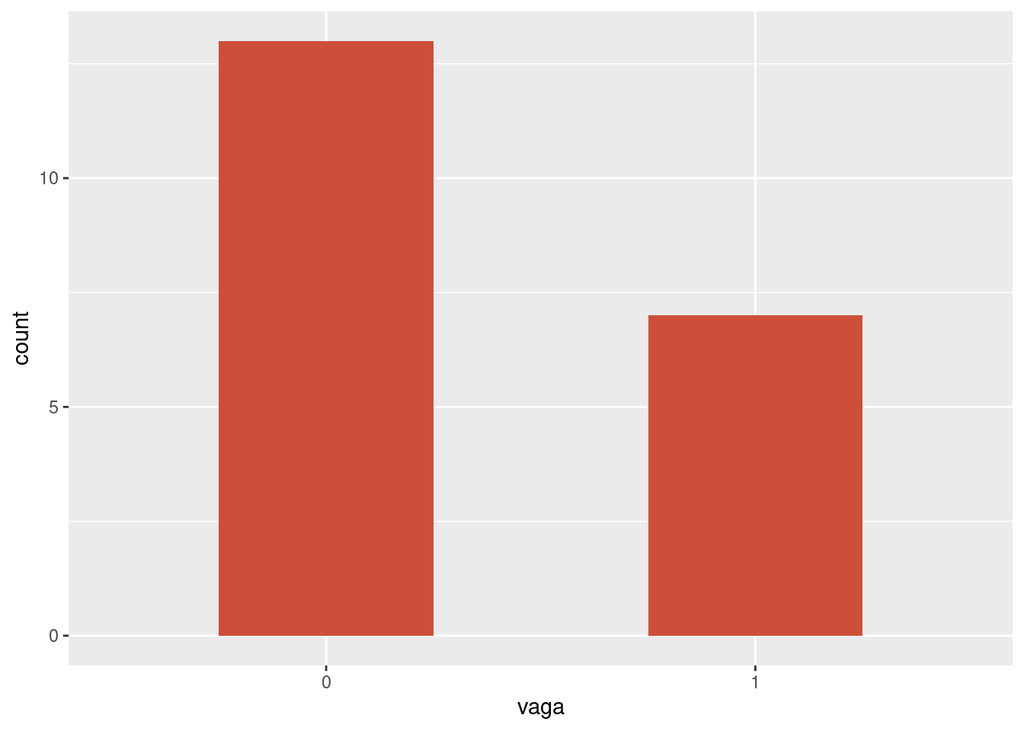

```r
ggplot(df, aes(x=vaga)) +
  geom_bar(stat="count", width=.5, fill="tomato3")
```

Podemos também usar cores de barras diferentes para representar categorias. Para usar categorias como argumentos no ggplot, é em geral interessante formatar os dados como dataframes long (uma variável por linha). Então, primeiramente vamos transformar o dataframe `df_mensal` definido no começo:

```r
library(tidyr)

df_long <- df_mensal %>%
  pivot_longer(!mes, names_to = "tipo", values_to = "valor")

df_long
```

```
## # A tibble: 8 × 3
##   mes        tipo       valor
##   <date>     <chr>      <dbl>
## 1 2017-07-01 aluguel     670
## 2 2017-07-01 condominio  314.
## 3 2017-08-01 aluguel    1000
## 4 2017-08-01 condominio  346
## 5 2017-09-01 aluguel     942
## 6 2017-09-01 condominio  269.
## 7 2017-10-01 aluguel     980
## 8 2017-10-01 condominio  414.
```

Agora podemos usar a variável tipo para distinguir o tipo de despesa (condomínio ou aluguel), com barras representando os valores médios por mês:

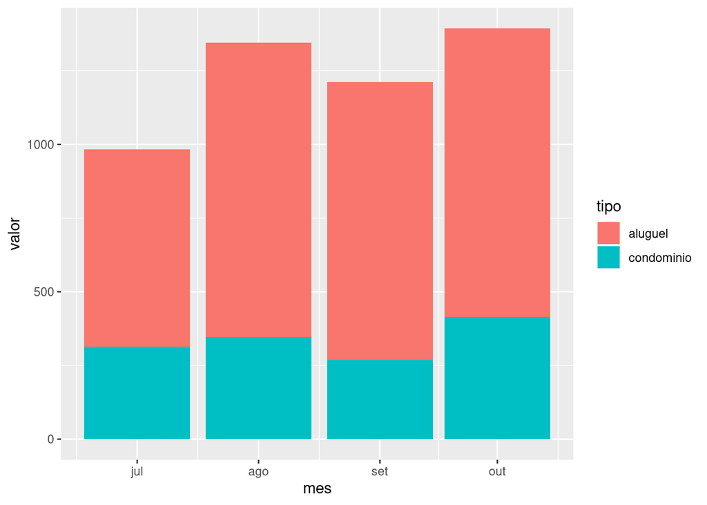

```r
ggplot(df_long, aes(x=mes, y=valor, fill=tipo)) +
  geom_bar(stat="identity")
```

Para exibir as barras separadamente, podemos usar o parâmetro `position=position_dodge()`:

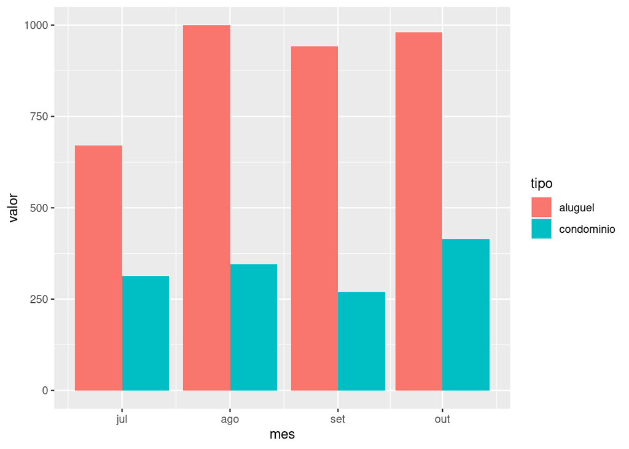

```r
ggplot(df_long, aes(x=mes, y=valor, fill=tipo)) +
  geom_bar(stat="identity", position=position_dodge())
```

# Séries temporais

Séries temporais são usualmente representadas com gráficos de linhas. O gráfico de linhas equivalente ao de barras apresentado anteriormente seria:

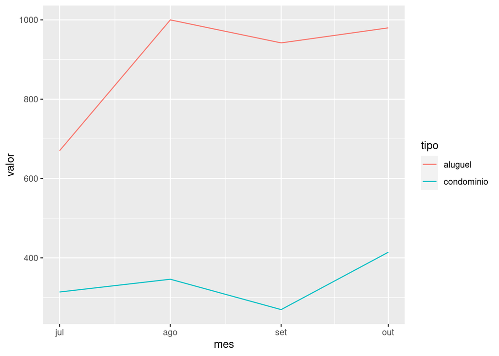

```r
ggplot(df_long, aes(x=mes, y=valor, color=tipo)) +
  geom_line(stat="identity")
```

É comum exibir séries temporais em gráficos separados, como abaixo. A função `facet_grid()` pode ser usada para isto (ela também pode ser usada com outros tipos de gráficos):

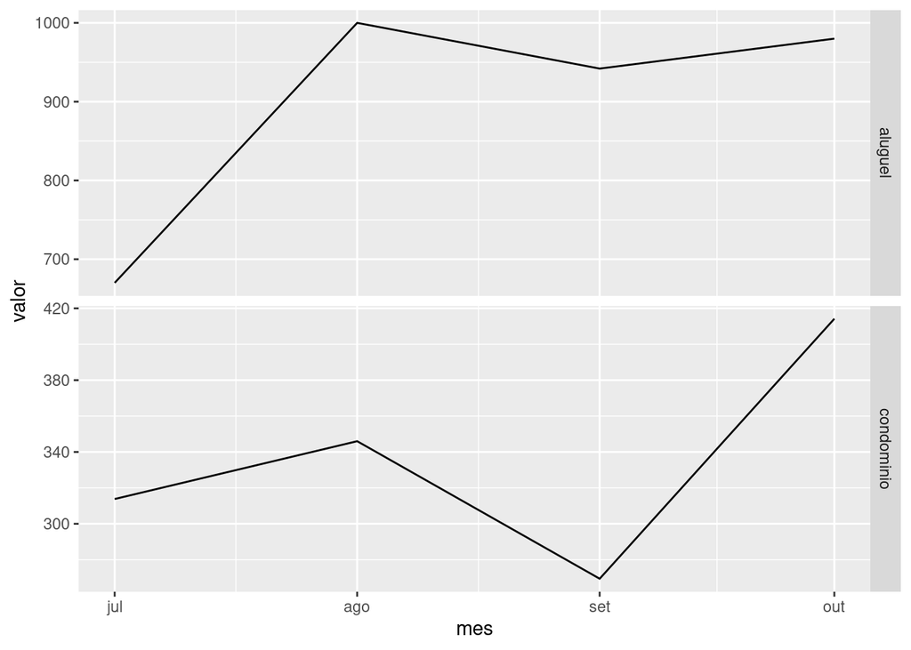

```r
ggplot(df_long, aes(x=mes, y=valor)) +
  geom_line(stat="identity") +
  facet_grid(tipo ~ ., scales="free")
```

# Distribuição

Além dos histogramas, apresentados anteriormente, box plots são muito usados para se estudar as distribuições das variáveis. No exemplo abaixo definimos box plots para o valor do aluguel estratificado pelo número de quartos e existência de vaga de garagem.

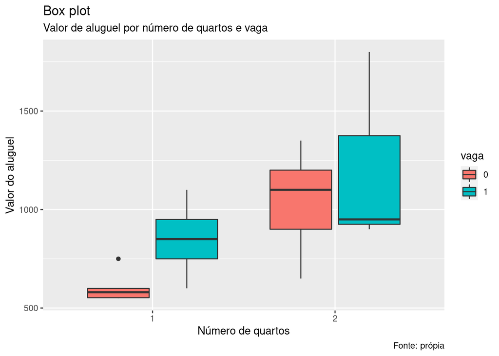

```r
g <- ggplot(df, aes(x=factor(quartos), y=aluguel, fill=vaga))
g + geom_boxplot() +
    labs(title="Box plot",
         subtitle="Valor de aluguel por número de quartos e vaga",
         caption="Fonte: própia",
         x="Número de quartos",
         y="Valor do aluguel")
```

Uma alternativa ao box plot que deixa a distribuição dos valores de uma forma mais simples de interpretar é o violin plot, como o definido abaixo:

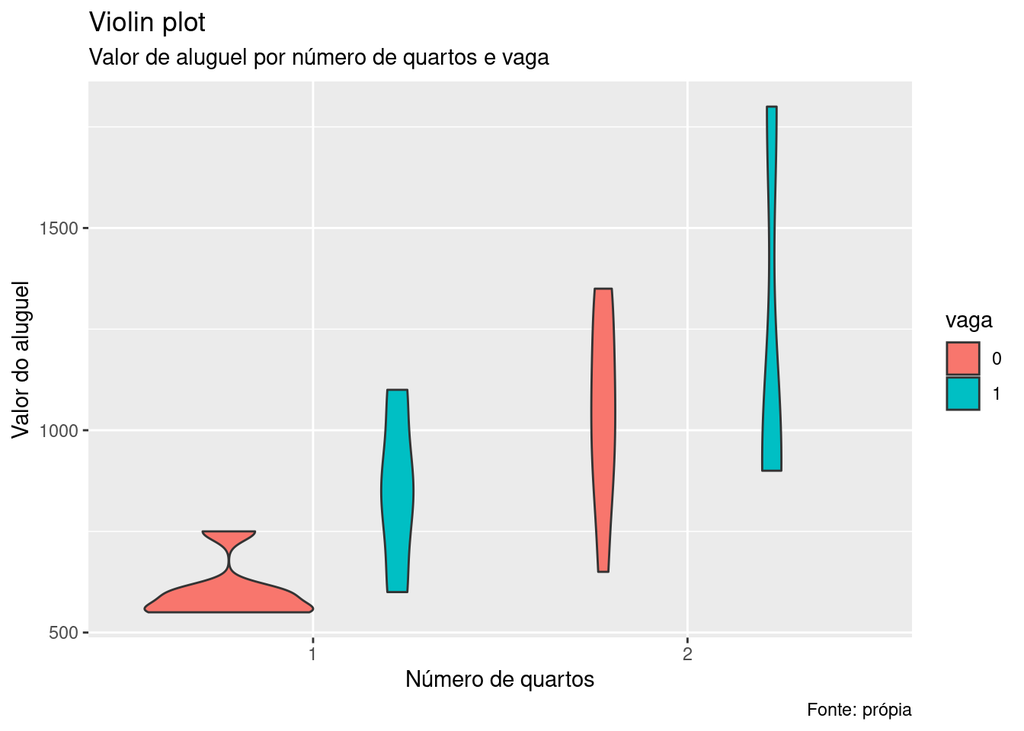

```r
g <- ggplot(df, aes(x=factor(quartos), y=aluguel, fill=vaga))
g + geom_violin() +
    labs(title="Violin plot",
         subtitle="Valor de aluguel por número de quartos e vaga",
         caption="Fonte: própia",
         x="Número de quartos",
         y="Valor do aluguel")
```